# Exploring the Link Between Household and Climate Change Factors and Educational Achievement in Rural Pakistan: A PCA and Logistic Regression Study

## 5.15 Step 11: Correlation Matrix for the final dataset

The correlation matrix is used to check for multicollinearity between the components. The Variance Inflation Factor (VIF) is used to check for multicollinearity between the components. A VIF value greater than 5 indicates multicollinearity.

```r
final_cor_aser <- final_aser_child_household_tib_balanced[,2:4]  # Exclude outcome variable, GeneralKnowledge, for corrlation
corr_aser_final <- cor(final_cor_aser)
corr_aser_final #all r<0.7, no munlticollinearity, ready for next step
```

```
##                        climate_change_factors household_vehicles people_time
## climate_change_factors              1.0000000         0.22966803  0.15293579
## household_vehicles                  0.2296680         1.00000000 -0.02449072
## people_time                         0.1529358        -0.02449072  1.00000000
```

```r
car::vif(lm(climate_change_factors ~ household_vehicles + people_time, data = final_aser_child_household_tib_balanced)) # moderate correlation >1
```

```
## household_vehicles        people_time
##             1.0006             1.0006
```

```r
#overall low correlations between the components but no multicollinearity issue
```

The correlations between the factors are low, with no multicollinearity issues r<0.7. The VIF value is less than 5, indicating that there is no multicollinearity between the components.

## 5.16 Step 12: Cross-validated logistic regression

```r
library(caret)
set.seed(123)

# Set up 10-fold cross-validation
train.control <- trainControl(method = "cv", number = 10, verbose = FALSE)
# method = cross validation, number = ten times (10 fold cross-validation)

# Logistic regression with stepwise selection
lr_cv10 <- train(GeneralKnolwedge ~ .,
                 data = final_aser_child_household_tib_balanced,
                 method = "glmStepAIC",
                 direction = "backward",
                 trControl = train.control,
                 family = "binomial",
                 verbose = FALSE
)
```

```r
# Cross-validated model results
lr_cv10 # kappa is 0.16 and accuracy is 0.58
```

```
## Generalized Linear Model with Stepwise Feature Selection
##
## 2350 samples
##    3 predictor
##    2 classes: '0', '1'
##
## No pre-processing
## Resampling: Cross-Validated (10 fold)
## Summary of sample sizes: 2115, 2114, 2115, 2116, 2115, 2115, ...
## Resampling results:
##
##   Accuracy   Kappa
##   0.5723065  0.1446917
```

```r
#print(lr_cv10$finalModel) # Final model)
summary(lr_cv10$finalModel) # Coefficients and model summary
```

```
##
## Call:
## NULL
##
## Coefficients:
##                    Estimate Std. Error z value Pr(>|z|)
## (Intercept)        0.003161   0.042346   0.075    0.941
## household_vehicles 0.498194   0.047941  10.392   <2e-16 ***
## ---
## Signif. codes:  0 '***' 0.001 '**' 0.01 '*' 0.05 '.' 0.1 ' ' 1
##
## (Dispersion parameter for binomial family taken to be 1)
##
##     Null deviance: 3257.8  on 2349  degrees of freedom
## Residual deviance: 3134.2  on 2348  degrees of freedom
## AIC: 3138.2
##
## Number of Fisher Scoring iterations: 4
```

The stepwise logistic regression model removed the two components, climate change factors, and the displacement factors, leaving only the household vehicles component as a significant predictor of general knowledge.

## 5.17 Step 13: Confusion Matrix

```r
#get predicted values
predicted <- unname(lr_cv10$finalModel$fitted.values) #change from a named number vector
#print(predicted)

#add predicted values to tibble

final_aser_child_household_tib_balanced$predicted.probabilities <- predicted


final_aser_child_household_tib_balanced <- final_aser_child_household_tib_balanced %>%
  mutate(actual = ifelse(GeneralKnolwedge == "1", 1, 0)) %>%
  #assign 0 to .50 and less and 1 to anything else
  mutate(predicted = ifelse(predicted.probabilities > 0.5, 1, 0)) #criteria is arbitary, but >0.5 means that the child is exhibiting general knowledge


#both need to be factors
final_aser_child_household_tib_balanced$predicted <- as.factor(final_aser_child_household_tib_balanced$predicted)
final_aser_child_household_tib_balanced$actual <- as.factor(final_aser_child_household_tib_balanced$actual)

glimpse(final_aser_child_household_tib_balanced)
```

```
## Rows: 2,350
## Columns: 7
## $ GeneralKnolwedge        <fct> 0, 0, 0, 0, 0, 0, 0, 0, 0, 0, 0, 0, 0, 0, 0, 0…
## $ climate_change_factors  <dbl> -0.75997649, -2.43690218, -0.37748475, -1.3518…
## $ household_vehicles      <dbl> -0.27308760, -1.12240523, -1.21478167, -0.7361…
## $ people_time             <dbl> -1.66326583, -0.20348888, -0.06742178, 1.41330…
## $ predicted.probabilities <dbl> 0.4668263, 0.3644700, 0.3538779, 0.4100921, 0.…
## $ actual                  <fct> 0, 0, 0, 0, 0, 0, 0, 0, 0, 0, 0, 0, 0, 0, 0, 0…
## $ predicted               <fct> 0, 0, 0, 0, 1, 1, 0, 1, 1, 0, 1, 0, 0, 0, 0, 1…
```

```r
table(final_aser_child_household_tib_balanced$actual) #what are final numbers
```

```
##
##    0    1
## 1175 1175
```

```r
# create confusion matrix using CARET
confusionMatrix(final_aser_child_household_tib_balanced$actual, final_aser_child_household_tib_balanced$predicted,
                mode = "everything", #what you want to report in stats
                positive="1") #positive here is some general knowledge
```

```
## Confusion Matrix and Statistics
##
##           Reference
## Prediction   0   1
##          0 642 533
##          1 452 723
##
##                Accuracy : 0.5809
##                  95% CI : (0.5606, 0.6009)
##     No Information Rate : 0.5345
##     P-Value [Acc > NIR] : 3.409e-06
##
##                   Kappa : 0.1617
##
##  Mcnemar's Test P-Value : 0.0108
##
##             Sensitivity : 0.5756
##             Specificity : 0.5868
##          Pos Pred Value : 0.6153
##          Neg Pred Value : 0.5464
##               Precision : 0.6153
##                  Recall : 0.5756
##                      F1 : 0.5948
##              Prevalence : 0.5345
##          Detection Rate : 0.3077
##    Detection Prevalence : 0.5000
##       Balanced Accuracy : 0.5812
##
##        'Positive' Class : 1
##
```

The low Kappa value (0.16) suggests that there is only slight agreement between predicted and actual values, adjusted for chance. Similarly, the low accuracy (0.58) suggests that the model is not highly accurate in predicting whether a student exhibits general knowledge or not.

## 5.18 Step 14: Final Model Interpretation

```r
final_aser_model <- lr_cv10$finalModel
summary(final_aser_model) # household_vehicles is the only significant variable
```

```
##
## Call:
## NULL
##
## Coefficients:
##                    Estimate Std. Error z value Pr(>|z|)
## (Intercept)        0.003161   0.042346   0.075    0.941
## household_vehicles 0.498194   0.047941  10.392   <2e-16 ***
## ---
## Signif. codes:  0 '***' 0.001 '**' 0.01 '*' 0.05 '.' 0.1 ' ' 1
##
## (Dispersion parameter for binomial family taken to be 1)
##
##     Null deviance: 3257.8  on 2349  degrees of freedom
## Residual deviance: 3134.2  on 2348  degrees of freedom
## AIC: 3138.2
##
## Number of Fisher Scoring iterations: 4
```

household_vehicles is the only significant variable. We are going to compute probabilities to understand the effect of household vehicles on the likelihood of a student exhibiting general knowledge.

```r
exp(final_aser_model$coefficients)
```

```
##        (Intercept) household_vehicles
##           1.003166           1.645747
```

```r
#create function for computing probabilities
probabilities <- function(coef) {
  odds <- exp(coef)
  prob <- odds / (1 + odds)
  return(prob)
}

#compute probabilities
probabilities(final_aser_model$coefficients)
```

```
##        (Intercept) household_vehicles
##          0.5007902          0.6220349
```

## 5.19 Step 15: Mosaic Plot

```r
#put the actual and predicted values into a table
mosaic_table <- table(final_aser_child_household_tib_balanced$actual, final_aser_child_household_tib_balanced$predicted)
mosaic_table #check on that table
```

```
##
##       0   1
##   0 642 533
##   1 452 723
```

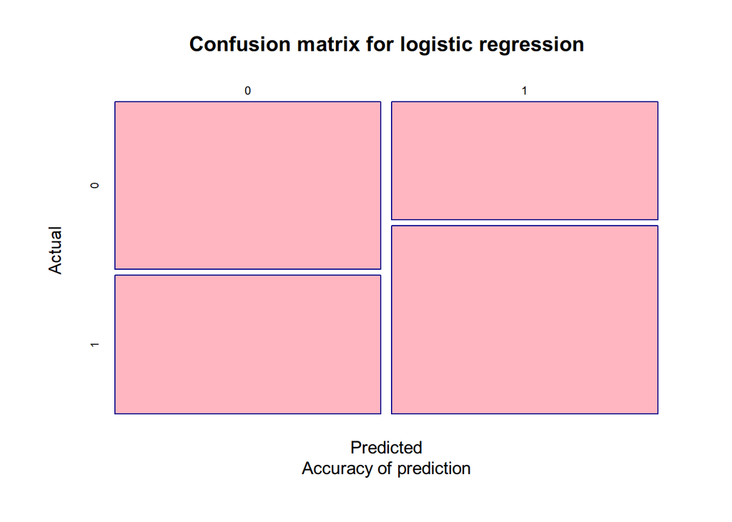

```r
#simple mosaic plot
mosaicplot(mosaic_table,
           main = "Confusion matrix for logistic regression",
           sub = "Accuracy of prediction",
           xlab = "Predicted",
           ylab = "Actual",
           color = "lightpink",
           border = "darkblue")
```

# 6 Conclusion

Since the household vehicles was a significant factor in determining general knowledge, it means that there is a potential association between access to vehicles and educational outcomes reflecting the impact of socioeconomic factors on a student’s educational outcome.